# IS-680_FALL_MIDTERM_V_SAI_PRANAV

```r
require(tidyverse)
movies=read_csv(url('https://ygenc.github.io/lectures/data/movies.csv'))
```

Loading the data

```r
movies
```

| year | imdb | title | test | clean_test | binary | budget | domgross | intgross | code | budget_2013 | domgross_2013 | intgross_2013 | period_code | decade_code |
| --- | --- | --- | --- | --- | --- | --- | --- | --- | --- | --- | --- | --- | --- | --- |
| 2013 | tt1711425 | 21 & Over | notalk | notalk | FAIL | 13000000 | 25682380 | 42195766 | 2013FAIL | 13000000 | 25682380 | 42195766 | 1 | 1 |
| 2012 | tt1343727 | Dredd 3D | ok-disagree | ok | PASS | 45000000 | 13414714 | 40868994 | 2012PASS | 45658735 | 13611086 | 41467257 | 1 | 1 |
| 2013 | tt2024544 | 12 Years a Slave | notalk-disagree | notalk | FAIL | 20000000 | 53107035 | 158607035 | 2013FAIL | 20000000 | 53107035 | 158607035 | 1 | 1 |
| 2013 | tt1272878 | 2 Guns | notalk | notalk | FAIL | 61000000 | 75612460 | 132493015 | 2013FAIL | 61000000 | 75612460 | 132493015 | 1 | 1 |
| 2013 | tt0453562 | 42 | men | men | FAIL | 40000000 | 95020213 | 95020213 | 2013FAIL | 40000000 | 95020213 | 95020213 | 1 | 1 |
| 2013 | tt1335975 | 47 Ronin | men | men | FAIL | 225000000 | 38362475 | 145803842 | 2013FAIL | 225000000 | 38362475 | 145803842 | 1 | 1 |
| 2013 | tt1606378 | A Good Day to Die Hard | notalk | notalk | FAIL | 92000000 | 67349198 | 304249198 | 2013FAIL | 92000000 | 67349198 | 304249198 | 1 | 1 |
| 2013 | tt2194499 | About Time | ok-disagree | ok | PASS | 12000000 | 15323921 | 87324746 | 2013PASS | 12000000 | 15323921 | 87324746 | 1 | 1 |
| 2013 | tt1814621 | Admission | ok | ok | PASS | 13000000 | 18007317 | 18007317 | 2013PASS | 13000000 | 18007317 | 18007317 | 1 | 1 |
| 2013 | tt1815862 | After Earth | notalk | notalk | FAIL | 130000000 | 60522097 | 244373198 | 2013FAIL | 130000000 | 60522097 | 244373198 | 1 | 1 |

[output cut: 990 more lines]

**QUESTION_1**

**A**

```r
glimpse(movies)
```

```
Rows: 1,794
Columns: 15
$ year          <dbl> 2013, 2012, 2013, 2013, 2013, 2013, 2013, 2013, 2013, 2013, 2013, 2013, 2013, 2013, 2013,~
$ imdb          <chr> "tt1711425", "tt1343727", "tt2024544", "tt1272878", "tt0453562", "tt1335975", "tt1606378"~
$ title         <chr> "21 & Over", "Dredd 3D", "12 Years a Slave", "2 Guns", "42", "47 Ronin", "A Good Day to D~
$ test          <chr> "notalk", "ok-disagree", "notalk-disagree", "notalk", "men", "men", "notalk", "ok-disagre~
$ clean_test    <chr> "notalk", "ok", "notalk", "notalk", "men", "men", "notalk", "ok", "ok", "notalk", "ok", "~
$ binary        <chr> "FAIL", "PASS", "FAIL", "FAIL", "FAIL", "FAIL", "FAIL", "PASS", "PASS", "FAIL", "PASS", "~
$ budget        <dbl> 1.30e+07, 4.50e+07, 2.00e+07, 6.10e+07, 4.00e+07, 2.25e+08, 9.20e+07, 1.20e+07, 1.30e+07,~
$ domgross      <dbl> 25682380, 13414714, 53107035, 75612460, 95020213, 38362475, 67349198, 15323921, 18007317,~
$ intgross      <dbl> 42195766, 40868994, 158607035, 132493015, 95020213, 145803842, 304249198, 87324746, 18007~
$ code          <chr> "2013FAIL", "2012PASS", "2013FAIL", "2013FAIL", "2013FAIL", "2013FAIL", "2013FAIL", "2013~
$ budget_2013   <dbl> 13000000, 45658735, 20000000, 61000000, 40000000, 225000000, 92000000, 12000000, 13000000~
$ domgross_2013 <dbl> 25682380, 13611086, 53107035, 75612460, 95020213, 38362475, 67349198, 15323921, 18007317,~
$ intgross_2013 <dbl> 42195766, 41467257, 158607035, 132493015, 95020213, 145803842, 304249198, 87324746, 18007~
$ period_code   <dbl> 1, 1, 1, 1, 1, 1, 1, 1, 1, 1, 1, 1, 1, 1, 1, 1, 1, 1, 1, 1, 1, 1, 1, 1, 1, 1, 1, 1, 1, 1,~
$ decade_code   <dbl> 1, 1, 1, 1, 1, 1, 1, 1, 1, 1, 1, 1, 1, 1, 1, 1, 1, 1, 1, 1, 1, 1, 1, 1, 1, 1, 1, 1, 1, 1,~
```

```r
str(movies)
```

```
spec_tbl_df [1,794 x 15] (S3: spec_tbl_df/tbl_df/tbl/data.frame)
 $ year         : num [1:1794] 2013 2012 2013 2013 2013 ...
 $ imdb         : chr [1:1794] "tt1711425" "tt1343727" "tt2024544" "tt1272878" ...
 $ title        : chr [1:1794] "21 & Over" "Dredd 3D" "12 Years a Slave" "2 Guns" ...
 $ test         : chr [1:1794] "notalk" "ok-disagree" "notalk-disagree" "notalk" ...
 $ clean_test   : chr [1:1794] "notalk" "ok" "notalk" "notalk" ...
 $ binary       : chr [1:1794] "FAIL" "PASS" "FAIL" "FAIL" ...
 $ budget       : num [1:1794] 1.30e+07 4.50e+07 2.00e+07 6.10e+07 4.00e+07 2.25e+08 9.20e+07 1.20e+07 1.30e+07 1.30e+08 ...
 $ domgross     : num [1:1794] 25682380 13414714 53107035 75612460 95020213 ...
 $ intgross     : num [1:1794] 4.22e+07 4.09e+07 1.59e+08 1.32e+08 9.50e+07 ...
 $ code         : chr [1:1794] "2013FAIL" "2012PASS" "2013FAIL" "2013FAIL" ...
 $ budget_2013  : num [1:1794] 13000000 45658735 20000000 61000000 40000000 ...
 $ domgross_2013: num [1:1794] 25682380 13611086 53107035 75612460 95020213 ...
 $ intgross_2013: num [1:1794] 4.22e+07 4.15e+07 1.59e+08 1.32e+08 9.50e+07 ...
 $ period_code  : num [1:1794] 1 1 1 1 1 1 1 1 1 1 ...
 $ decade_code  : num [1:1794] 1 1 1 1 1 1 1 1 1 1 ...
 - attr(*, "spec")=
  .. cols(
  ..   year = col_double(),
  ..   imdb = col_character(),
  ..   title = col_character(),
  ..   test = col_character(),
  ..   clean_test = col_character(),
  ..   binary = col_character(),
  ..   budget = col_double(),
  ..   domgross = col_double(),
  ..   intgross = col_double(),
  ..   code = col_character(),
  ..   budget_2013 = col_double(),
  ..   domgross_2013 = col_double(),
  ..   intgross_2013 = col_double(),
  ..   period_code = col_double(),
  ..   decade_code = col_double()
  .. )
 - attr(*, "problems")=<externalptr>
```

As we have used str() and glimpse we can see the datatypes of the columns in movies.

```r
names(movies)
```

```
 [1] "year"          "imdb"          "title"         "test"          "clean_test"    "binary"
 [7] "budget"        "domgross"      "intgross"      "code"          "budget_2013"   "domgross_2013"
[13] "intgross_2013" "period_code"   "decade_code"
```

**B**

```r
ncol(movies)
```

```
[1] 15
```

With ncol() we can check the number of the columns in the dataframe

```r
nrow(movies)
```

```
[1] 1794
```

With nrow() we can check the number of the rows in the dataframe

**C**

```r
movies_1 <- movies
```

making copy of data frame so that actual data does not affect

```r
category <- cut(movies_1$budget_2013, breaks = 3, labels = c("low","medium","high"))
table(category)
```

```
category
   low medium   high
  1671    121      2
```

As you can see above, We have used cut() function in-order to transform the numerical value to categorical value by dividing the budget_2013 to low budgeted, medium budgeted and high budgeted films.

```r
movies_1$budget_2013[1:10]
```

```
 [1]  13000000  45658735  20000000  61000000  40000000 225000000  92000000  12000000  13000000 130000000
```

```r
category[1:10]
```

```
 [1] low    low    low    low    low    medium low    low    low    low
Levels: low medium high
```

The above two chucks compares the first 10 rows that are in numerical and categorical format.

**QUESTION2**

**A**

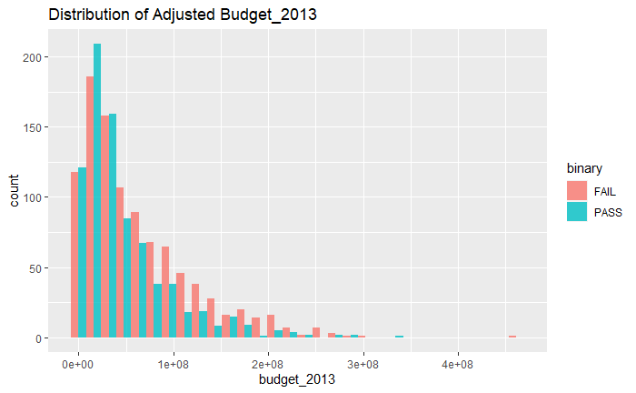

```r
ggplot(movies, aes(x = budget_2013, fill = binary)) +
  geom_histogram(position = "dodge",alpha = 0.8) +
  ggtitle("Distribution of Adjusted Budget_2013")
```

In the above graph we have examined the distribution using histograms based on whether the movie has passed or failed the bechdel test.